# Basic R Programming (v4.0)

Author: Chiachun Chiu (chiachun.chiu@gmail.com)

2025-08-11

## Before this course

- 歡迎任何問題，課程中有問題請隨時到[臉書](https://www.facebook.com/godkin1211/) 上問我。

## About R

> [R](http://www.r-project.org/about.html) is a **language** and **environment** for statistical computing and graphics. It is a GNU project which is similar to the S language and environment which was developed at Bell Laboratories (formerly AT&T, now Lucent Technologies) by John Chambers and colleagues. R can be considered as a different implementation of S. There are some important differences, but much code written for S runs unaltered under R. …… R is available as Free Software under the terms of the Free Software Foundation’s GNU General Public License in source code form. It compiles and runs on a wide variety of UNIX platforms and similar systems (including FreeBSD and Linux), Windows and MacOS.

#### R-4.5.1 was released since 2025 June.

## How/where to obtain and install R?

If you use linux as your default os, you can install R from the package repositories of each distribution directly. Alternatively, you can download R binary-version or source code from **CRAN** if you use M$ windows or Mac OS.

#### Ubuntu users

- Update indices with `sudo apt update -qq`
- Install two helper packages we need `sudo apt install --no-install-recommends software-properties-common dirmngr`
- Add the signing key with `wget -qO- https://cloud.r-project.org/bin/linux/ubuntu/marutter_pubkey.asc | sudo tee -a /etc/apt/trusted.gpg.d/cran_ubuntu_key.asc`
- Add the repo from CRAN with `sudo add-apt-repository "deb https://cloud.r-project.org/bin/linux/ubuntu $(lsb_release -cs)-cran40/"`
- Install R with `sudo apt install --no-install-recommends r-base r-base-dev`

#### MacOS users

- Intel x86-64: **R-4.5.1-x86_64.pkg**
- Apple silicon arm64: **R-4.5.1-arm64.pkg**
  - To compile R packages which contain Fortran code, Xcode 16.2 and [**arm64**-version GNU Fortran14.2](https://mac.r-project.org/tools/) is required.
  - [XQuartz](https://www.xquartz.org/) >= 2.8.5 is required to use X11 (including `tcltk`).

#### Windows users

- Download the latest version of R from [CRAN](https://cran.r-project.org/bin/windows/base/)
- Install R with the downloaded installer
- Install Rtools from [CRAN](https://cran.r-project.org/bin/windows/Rtools/)
  - Rtools is a collection of tools for building R packages on Windows. It includes a compiler, a set of libraries, and other tools that are needed to build R packages from source.
- Add Rtools to your PATH environment variable
  - Open the Control Panel and go to System and Security > System > Advanced system settings > Environment Variables.
  - Under System variables, find the PATH variable and click Edit.
  - Add the path to the Rtools bin directory (e.g., `C:\Rtools\bin`) to the PATH variable.
  - Click OK to save the changes.

#### CRAN Repositories

- Mirrors in Taiwan
  - [NTU](http://cran.csie.ntu.edu.tw/)
  - [YZU](http://ftp.yzu.edu.tw/CRAN/)

## Using RStudio as your default R-programming IDE

#### About [RStudio](http://www.rstudio.com/)

> RStudio is an integrated development environment (IDE) for R. It includes a console, syntax-highlighting editor that supports direct code execution, as well as tools for plotting, history, debugging and workspace management.

#### Install the most suitable version of RStudio for your needs.

- Desktop version: Access RStudio locally.
- Server version: Access via a web browser.

#### Other choices

[figure not shown]

- : [VS code](https://marketplace.visualstudio.com/items?itemName=Ikuyadeu.r)

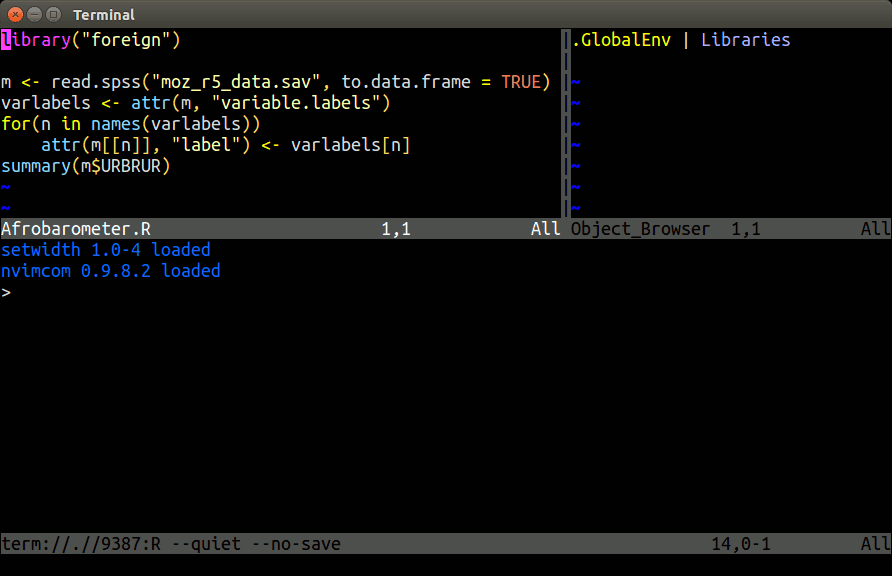

- : [Vim+Nvim-R](https://github.com/jalvesaq/Nvim-R)
- Any other text editors: gedit, emacs(+ESS), eclipse and etc.

## Resources of learning R

#### 1. Books & web sites

- [RDocumentation](https://www.rdocumentation.org/)
- [Introduction to Probability and Statistics Using R](http://ipsur.org/)
- [Introduction to Scientific Programming and Simulation Using R](http://www.amazon.com/Introduction-Scientific-Programming-Simulation-Chapman/dp/1420068725)
- [The Art of R Programming](http://www.amazon.com/The-Art-Programming-Statistical-Software/dp/1593273843)
- [R Tutorial](http://www.cyclismo.org/tutorial/R/)
- [Programming in R](http://manuals.bioinformatics.ucr.edu/home/programming-in-r)
- [Advanced R](http://adv-r.had.co.nz/)
- [Bioconductor Course Materials](https://bioconductor.org/help/course-materials/)

#### 2. Forums & communities

- [R-bloggers](http://www.r-bloggers.com/)
- [Taiwan R User Group](http://www.meetup.com/Taiwan-R)
- [Stack Overflow](http://stackoverflow.com/questions/tagged/r)
- [Ptt R_Language](https://www.ptt.cc/bbs/R_Language/index.html)
- [Taipei Bioinformatics Omnibus](https://www.facebook.com/groups/446434039038963)
- [Right Relevance](https://www.rightrelevance.com/)

#### 3. Blog & News

- [R Weekly](https://rweekly.org)
- [R语言中文社区](https://466874.kuaizhan.com/)
- [糗世界](http://216.49.144.90:8080/rbioconductor-2)
- [R的極客理想](http://blog.fens.me/series-r/)

#### LLM-based tools

- [Claude](https://claude.ai/)
- [Claude Code](https://www.anthropic.com/claude-code)

## The most important step when beginning to learn R is using help()

#### help() & help.search()

```r
help(help)
help.search("standard deviation")
```

#### ? & ??

```r
?mean
??hypergeometric
```

## Package installation & PATH setting

#### Installing packages in R console

```r
# Download Pkgs from CRAN repository & install
install.packages('rmarkdown',                        # Package name
                 repo="http://cran.csie.ntu.edu.tw", # The URL of CRAN repository
                 destdir="~/Download",               # The directory where downloaded pkgs are stored
                 lib=.libPaths()[1])                 # The directory where to install pkgs

# Install Pkgs from downloaded source code
install.packages('~/Download/rmarkdown_0.5.1.tar.gz',
                 repos=NULL,
                 type="source",
                 lib=.libPaths()[1])
```

#### Installing packages in terminal

```r
$ R CMD INSTALL -l $HOME/R/4.1 rmarkdown_0.5.1.tar.gz
```

#### Setting PATH

```r
.libPaths(new)  # .libPaths("/Library/Frameworks/R.framework/Versions/4.5-arm64/Resources/library")
```

#### Some Pkgs should be downloaded/installed from [R-forge](https://r-forge.r-project.org/)

Set `install.packages(Pkg, repo='http://R-Forge.R-project.org')`

#### Using the package installed

```r
library(Pkg)
require(Pkg) # Avoid to use this!
```

**[What is the difference between require() and library()](http://stackoverflow.com/questions/5595512/what-is-the-difference-between-require-and-library)**

## Bioconductor

#### About [Bioconductor](http://www.bioconductor.org/)

> Bioconductor provides tools for the analysis and comprehension of high-throughput genomic data. Bioconductor uses the R statistical programming language, and is open source and open development.

#### Install Pkgs from Bioconductor

```r
# Install BiocManager
install.packages("BiocManager")
BiocManager::install(pkgname)
```

#### Rich course materials

[Courses & conference](https://www.bioconductor.org/help/course-materials/)

[figure not shown]

## Basic operation

```r
5+5
5-3
5*3
5/3
5^3
10%%3

# Variable declaration
x <- 5 # '<-' is assign operator in R, which is equivalent to '='
y <- function(i) mean(i)
```

## Data and object types

#### Data types

- numeric: `c(1:3, 5 ,7)`
- character: `c("1","2","3"); LETTERS[1:3]`
- logical: `TRUE; FALSE`
- complex: 1, b, 3

#### Object types

- **vector**: the data types of all elements in a vector must be consistent!

```r
x <- 1:5
y <- c(6,7,8,9,10)
z <- x - y
print(z)
```

```
## [1] -5 -5 -5 -5 -5
```

```r
# Vectorized code performs better!
a <- 1:100000
system.time(mean(a))
```

```
##    user  system elapsed
##   0.000   0.000   0.001
```

```r
total <- 0
system.time(for (i in a) {total <- total + i; total/100000})
```

```
##    user  system elapsed
##   0.002   0.000   0.002
```

- **matrix**

```r
x <- matrix(rnorm(100), nr=20, nc=5)
print(x)
```

```
##             [,1]          [,2]        [,3]         [,4]        [,5]
##  [1,]  0.1015948  0.0642181149  0.56981790  0.075555402 -1.56558472
##  [2,]  0.8238494 -1.4541533993  0.77630298  0.740858112 -0.89661126
##  [3,] -2.0835686 -0.9864774920  0.52594617  0.460560644  1.40959197
##  [4,] -0.4871945 -1.4339066924 -0.55653589 -1.553996432  0.07640065
##  [5,]  0.6185140  0.0924342895  0.80520287 -0.258317038  1.15602578
##  [6,] -0.2015274  0.4927495339  1.71295631  0.505388306  0.81279898
##  [7,]  1.9813213 -0.9010289068 -0.27094501 -0.655100962 -0.91800020
##  [8,]  0.2599863  0.3845281721  0.35495410  0.383718733  0.70581047
##  [9,] -1.4444652 -0.2936074106  0.25944580 -1.282444949  0.97563458
## [10,] -0.4064867 -1.3479293593  0.14869627 -0.471054603 -1.02240968
## [11,] -0.4099183 -0.0002664301 -0.19555673 -1.344812505  0.07339349
## [12,]  0.4587322  0.6542851894  0.79900022  1.521973607  1.18790250
## [13,] -0.9464147 -0.8229221307  0.69249541  0.475064959 -0.06605164
## [14,] -1.1452701 -0.1307058494  0.66777464 -0.503321923  0.52968315
## [15,] -1.1281515  0.0647030198  0.46714555  1.625314945 -1.47153548
## [16,]  1.2335336  2.1396898760  0.25015893 -1.421175629  0.59080851
## [17,] -0.2261436  3.3388863564  0.93684898  0.023676072  1.25000706
## [18,] -0.1817232  0.2203438556  0.06756794  1.164954156 -0.72261360
## [19,]  1.1215216  0.8045512020 -0.30128344 -1.239919788  0.26773028
## [20,] -0.8726748  0.5539579898 -0.54451048  0.009346597 -1.86364947
```

```r
x[1,3]
x[2:4,]
x[,3:5]
x %*% t(x)

# A matrix is a vector with subscripts!
x[1:3]
x[1:3,1]
```

- **array**

```r
y <- array(rnorm(64), c(8,4,2))
print(y) # An array is also a vector with subscripts!
```

```
## , , 1
##
##            [,1]       [,2]        [,3]        [,4]
## [1,]  0.4350160 -0.1334197  0.50784606 -0.35071908
## [2,] -2.0925494 -0.3743607 -0.68094608 -1.04183890
## [3,]  1.9039302 -0.7458355 -1.54317301 -0.07209713
## [4,] -0.2225421  0.2934712 -0.14405286 -0.51810077
## [5,] -0.1666554  1.3017875 -0.08716959  1.20445641
## [6,] -0.7614566  0.4263463 -1.17660054 -0.74202563
## [7,]  0.2801477  1.1161116 -1.58882243 -0.09026542
## [8,]  0.1109337  0.1945871  1.18722507  0.26390819
##
## , , 2
##
##            [,1]        [,2]       [,3]        [,4]
## [1,] -2.0407405 -1.92991265  0.4693643 -0.41648909
## [2,]  0.6200939 -0.04779358  0.3476217  0.99003159
## [3,]  0.9695621  0.17640280 -0.1082669  0.31277115
## [4,] -0.6570059  0.18222666 -0.8635528  0.32116457
## [5,]  0.0112411  0.02739419  0.3911391 -0.01144461
## [6,]  1.2841623  0.50409830  1.5592843 -0.54518265
## [7,] -0.5943998 -0.36745143 -0.4777322 -1.53552195
## [8,] -0.4395505  0.94443299  2.0330774 -0.11069632
```

- **list**: the data types of elements in a list could be complex

```r
x<-list(1:5, c("a","b","c"), matrix(rnorm(10),nr=5,nc=2))
print(x)
```

```
## [[1]]
## [1] 1 2 3 4 5
##
## [[2]]
## [1] "a" "b" "c"
##
## [[3]]
##            [,1]      [,2]
## [1,] -1.4288184 1.0192663
## [2,] -1.5671665 2.5437858
## [3,] -0.2939959 0.2167372
## [4,] -0.6291326 2.3842487
## [5,] -2.3009308 0.6579837
```

```r
x$mylist <- x
print(x)
```

```
## [[1]]
## [1] 1 2 3 4 5
##
## [[2]]
## [1] "a" "b" "c"
##
## [[3]]
##            [,1]      [,2]
## [1,] -1.4288184 1.0192663
## [2,] -1.5671665 2.5437858
## [3,] -0.2939959 0.2167372
## [4,] -0.6291326 2.3842487
## [5,] -2.3009308 0.6579837
##
## $mylist
## $mylist[[1]]
## [1] 1 2 3 4 5
##
## $mylist[[2]]
## [1] "a" "b" "c"
##
## $mylist[[3]]
##            [,1]      [,2]
## [1,] -1.4288184 1.0192663
## [2,] -1.5671665 2.5437858
## [3,] -0.2939959 0.2167372
## [4,] -0.6291326 2.3842487
## [5,] -2.3009308 0.6579837
```

- **data frame**: a data frame is collection of multiple lists with the same length

```r
df<-data.frame(num=1:10,
           char=LETTERS[1:10],
           logic=sample(c(TRUE,FALSE), 10, replace=TRUE))

df
```

```
##    num char logic
## 1    1    A  TRUE
## 2    2    B  TRUE
## 3    3    C  TRUE
## 4    4    D  TRUE
## 5    5    E  TRUE
## 6    6    F  TRUE
## 7    7    G FALSE
## 8    8    H  TRUE
## 9    9    I FALSE
## 10  10    J  TRUE
```

```r
df$char
```

```
##  [1] "A" "B" "C" "D" "E" "F" "G" "H" "I" "J"
```

```r
df$logic[5:7]
```

```
## [1]  TRUE  TRUE FALSE
```

- **factor**: An R **factor** might be viewed simply as **a vector with a bit more information added** (though, as seen below, it’s different from this internally). That extra information consists of a record of the distinct values in that vector, called **levels**.

```r
x <- c(5, 12, 32, 12)
xf <- factor(x)
print(xf)
```

```
## [1] 5  12 32 12
## Levels: 5 12 32
```

So…. a factor looks like a vector, right?

```r
str(xf) # Here str stands for structure. This function shows the internal structure of any R object.
```

```
##  Factor w/ 3 levels "5","12","32": 1 2 3 2
```

```r
unclass(xf)
```

```
## [1] 1 2 3 2
## attr(,"levels")
## [1] "5"  "12" "32"
```

```r
length(xf)
```

```
## [1] 4
```

What??? What are you talking about?

```r
x <- c(5, 12, 13, 12)
xff <- factor(x, levels=c(5, 12, 13, 88))
xff
```

```
## [1] 5  12 13 12
## Levels: 5 12 13 88
```

```r
xff[2] <- 88
xff
```

```
## [1] 5  88 13 12
## Levels: 5 12 13 88
```

```r
xff[2] <- 28 # You cannot sneak in an "illegal" level
```

- **table**: Another common way to store information is in a table.

```r
# One way table
a <- factor(c("A","A","B","A","B","B","C","A","C"))
a
```

```
## [1] A A B A B B C A C
## Levels: A B C
```

```r
a.table <- table(a)
a.table
```

```
## a
## A B C
## 4 3 2
```

```r
attributes(a.table)
```

```
## $dim
## [1] 3
##
## $dimnames
## $dimnames$a
## [1] "A" "B" "C"
##
##
## $class
## [1] "table"
```

```r
# Two way table
a <- c("Sometimes","Sometimes","Never","Always","Always","Sometimes","Sometimes","Never")
b <- c("Maybe","Maybe","Yes","Maybe","Maybe","No","Yes","No")
twoway.table <- table(a,b)
twoway.table
```

```
##            b
## a           Maybe No Yes
##   Always        2  0   0
##   Never         0  1   1
##   Sometimes     2  1   1
```

```r
# An example
sexsmoke<-matrix(c(70,120,65,140),ncol=2,byrow=TRUE)
rownames(sexsmoke)<-c("male","female")
colnames(sexsmoke)<-c("smoke","nosmoke")
sexsmoke <- as.table(sexsmoke)
sexsmoke
```

```
##        smoke nosmoke
## male      70     120
## female    65     140
```

## Control structures

#### Conditional excutions

- **equal**: ==
- **not equal**: !=
- **greater/less than**: >, <
- **greater/less than or equal**: >=, <=

#### Logical operators

- **and**: &, &&
- **or**: |, ||
- **not**: !

#### if-else statements

```r
if (cond1==TRUE) {cmd1} else {cmd2}
```

```r
# Example
if (1 == 0) {
    print(1)
} else {
    print(2)
}
```

```
## [1] 2
```

#### ifelse statements (ternary operator in R)

```r
ifelse(test, true_value, false_value)
```

```r
x <- 1:10
ifelse(x<5|x>8, x, 0)
```

```
##  [1]  1  2  3  4  0  0  0  0  9 10
```

#### switch-case statements

```r
AA <- 'foo'
switch(AA,
       foo = {print('AA is foo')},
       bar = {print('AA is bar')},
       {print('Default')}
)
```

```
## [1] "AA is foo"
```

## Loops

#### For loop

```r
for (var in vector) {
    statement
}
```

```r
# Example
mydf <- iris
head(mydf)
```

```
##   Sepal.Length Sepal.Width Petal.Length Petal.Width Species
## 1          5.1         3.5          1.4         0.2  setosa
## 2          4.9         3.0          1.4         0.2  setosa
## 3          4.7         3.2          1.3         0.2  setosa
## 4          4.6         3.1          1.5         0.2  setosa
## 5          5.0         3.6          1.4         0.2  setosa
## 6          5.4         3.9          1.7         0.4  setosa
```

```r
myve <- NULL
for (i in 1:nrow(mydf)) {
    myve <- c(myve, mean(as.numeric(mydf[i, 1:3])))
}
myve
```

```
##   [1] 3.333333 3.100000 3.066667 3.066667 3.333333 3.666667 3.133333 3.300000
##   [9] 2.900000 3.166667 3.533333 3.266667 3.066667 2.800000 3.666667 3.866667
##  [17] 3.533333 3.333333 3.733333 3.466667 3.500000 3.433333 3.066667 3.366667
##  [25] 3.366667 3.200000 3.333333 3.400000 3.333333 3.166667 3.166667 3.433333
##  [33] 3.600000 3.700000 3.166667 3.133333 3.433333 3.300000 2.900000 3.333333
##  [41] 3.266667 2.700000 2.966667 3.366667 3.600000 3.066667 3.500000 3.066667
##  [49] 3.500000 3.233333 4.966667 4.700000 4.966667 3.933333 4.633333 4.333333
##  [57] 4.766667 3.533333 4.700000 3.933333 3.500000 4.366667 4.066667 4.566667
##  [65] 4.033333 4.733333 4.366667 4.200000 4.300000 4.000000 4.633333 4.300000
##  [73] 4.566667 4.533333 4.533333 4.666667 4.800000 4.900000 4.466667 3.933333
##  [81] 3.900000 3.866667 4.133333 4.600000 4.300000 4.633333 4.833333 4.333333
##  [89] 4.233333 4.000000 4.166667 4.566667 4.133333 3.533333 4.166667 4.300000
##  [97] 4.266667 4.466667 3.533333 4.200000 5.200000 4.533333 5.333333 4.933333
## [105] 5.100000 5.733333 3.966667 5.500000 5.000000 5.633333 4.933333 4.800000
## [113] 5.100000 4.400000 4.566667 4.966667 5.000000 6.066667 5.733333 4.400000
## [121] 5.266667 4.433333 5.733333 4.633333 5.233333 5.466667 4.600000 4.666667
## [129] 4.933333 5.333333 5.433333 6.033333 4.933333 4.733333 4.766667 5.600000
## [137] 5.100000 5.000000 4.600000 5.133333 5.133333 5.033333 4.533333 5.300000
## [145] 5.233333 4.966667 4.600000 4.900000 5.000000 4.666667
```

#### while loop

```r
while (condition) statements
```

```r
# Example
z <- 0
while (z < 5) {
    z <- z + 2
    print(z)
}
```

```
## [1] 2
## [1] 4
## [1] 6
```

#### apply loop

##### For matrix/array

```r
apply(X, MARGIN, FUN, ARGS)

# Examples
apply(iris[,1:3], 1, mean)

x <- 1:10

apply(as.matrix(x), 1, function(i) {
    if (i < 5)
        i - 1
    else
        i/i
})
```

##### For vector/list

```r
lapply(X, FUN)
sapply(X, FUN)
```

```r
# Examples
mylist <- as.list(iris[1:3, 1:3])
mylist
```

```
## $Sepal.Length
## [1] 5.1 4.9 4.7
##
## $Sepal.Width
## [1] 3.5 3.0 3.2
##
## $Petal.Length
## [1] 1.4 1.4 1.3
```

```r
lapply(mylist, sum) # Compute sum of each list component and return result as list
```

```
## $Sepal.Length
## [1] 14.7
##
## $Sepal.Width
## [1] 9.7
##
## $Petal.Length
## [1] 4.1
```

```r
sapply(mylist, sum) # Compute sum of each list component and return result as vector
```

```
## Sepal.Length  Sepal.Width Petal.Length
##         14.7          9.7          4.1
```

##### More apply functions

- **tapply**
- **mapply**

## function

```r
FunctionName <- function(arg1, arg2, ...) {
    statements
    return(R_object)
}
```

```r
add <- function(a, b) {
    c <- a + b
    return(c)
}
x <- 5
y <- 7
z <- add(x,y)
z
```

```
## [1] 12
```

## Advanced R programming

#### Garbage collection

- **rm()**
- **gc()**

```r
x <- as.matrix(read.table("test.csv", sep="\t")) # x is a 4500000 x 220 matrix
y <- apply(x, 1, mean)
rm(list=c("x","y"))
gc()
```

#### Use data.table to speed up acquisition of data

##### See [Introduction to the data.table package in R](http://cran.r-project.org/web/packages/data.table/vignettes/datatable-intro.pdf)

> Fast aggregation of large data (e.g. 100GB in RAM), fast ordered joins, fast add/modify/delete of columns by group using no copies at all, list columns and a fast file reader (fread). Offers a natural and flexible syntax, for faster development. - from [CRAN](http://cran.r-project.org/web/packages/data.table/index.html)

```r
library(data.table)
grpsize <- ceiling(1e7/26^2)
DF <- data.frame(
    x=rep(LETTERS, each=26*grpsize),
    y=rep(letters, each=grpsize),
    v=runif(grpsize*26^2),
    stringsAsFactors=FALSE)
system.time(ans1 <- DF[DF$x=="R" & DF$y=="h",])
```

```
##    user  system elapsed
##   0.058   0.010   0.068
```

```r
DT <- as.data.table(DF)
setkey(DT, x, y)
system.time(ans2 <- DT[list("R","h")])
```

```
##    user  system elapsed
##   0.014   0.000   0.004
```